# Practical Machine Learning Project Writeup

Alexey Maloletkin

August 21, 2015

# Project

## Goal

The goal of this project is to predict the manner in which they did the exercise. This is the “classe” variable in the training set. You may use any of the other variables to predict with. You should create a report describing how you built your model, how you used cross validation, what you think the expected out of sample error is, and why you made the choices you did. You will also use your prediction model to predict 20 different test cases.

## Background

From project assignment: “Using devices such as Jawbone Up, Nike FuelBand, and Fitbit it is now possible to collect a large amount of data about personal activity relatively inexpensively. These type of devices are part of the quantified self movement – a group of enthusiasts who take measurements about themselves regularly to improve their health, to find patterns in their behavior, or because they are tech geeks. One thing that people regularly do is quantify how much of a particular activity they do, but they rarely quantify how well they do it. In this project, your goal will be to use data from accelerometers on the belt, forearm, arm, and dumbell of 6 participants. They were asked to perform barbell lifts correctly and incorrectly in 5 different ways. More information is available from the website here: http://groupware.les.inf.puc-rio.br/har (see the section on the Weight Lifting Exercise Dataset).”

## Data Source

The training data for this project are available here: https://d396qusza40orc.cloudfront.net/predmachlearn/pml-training.csv

The test data are available here: https://d396qusza40orc.cloudfront.net/predmachlearn/pml-testing.csv

The data for this project come from this source: http://groupware.les.inf.puc-rio.br/har

# Getting data

```r
if (!length(list.files('.', pattern='pml-training.csv'))>0)
{
  fileUrl='https://d396qusza40orc.cloudfront.net/predmachlearn/pml-training.csv'
  download.file(url = fileUrl, method = 'curl', destfile = 'pml-training.csv')
  fileUrl='https://d396qusza40orc.cloudfront.net/predmachlearn/pml-testing.csv'
  download.file(url = fileUrl, method = 'curl', destfile = 'pml-testing.csv')
}
```

I did some initial data lookup into files to identify data structure/potential issues. Mostly related to NA vslues storing - I found in addition to NA there is a lot of empty values as well as #DIV/0!

```r
data <- read.csv(file="pml-training.csv", header=TRUE, sep=",", na.strings=c("NA","#DIV/0!","") )
test_data <- read.csv(file="pml-testing.csv", header=TRUE, sep=",", na.strings=c("NA","#DIV/0!","") )
```

Let’s check what size of data we loaded

```r
dim(data)
```

```
## [1] 19622   160
```

```r
dim(test_data)
```

```
## [1]  20 160
```

## Defining training and testing dataset

We will split dataset by classe in proportion 60% for training and 40% for testing/validation Let set seed first so data will be reproducable.

```r
set.seed(1234)
```

```r
inTrain = createDataPartition(data$classe, p = 0.6)[[1]]

training = data[inTrain, ]
testing = data[-inTrain, ]
```

Check size of training dataset

```r
dim(training)
```

```
## [1] 11776   160
```

## Install required packages

```r
if (!"caret" %in% installed.packages()) install.packages("caret",  dependencies = c("Depends", "Suggests"))
library(caret)
```

# Cleaning data and identifying predictors

## Removing book keeping variables

Looks like X is just index - let plot X to check

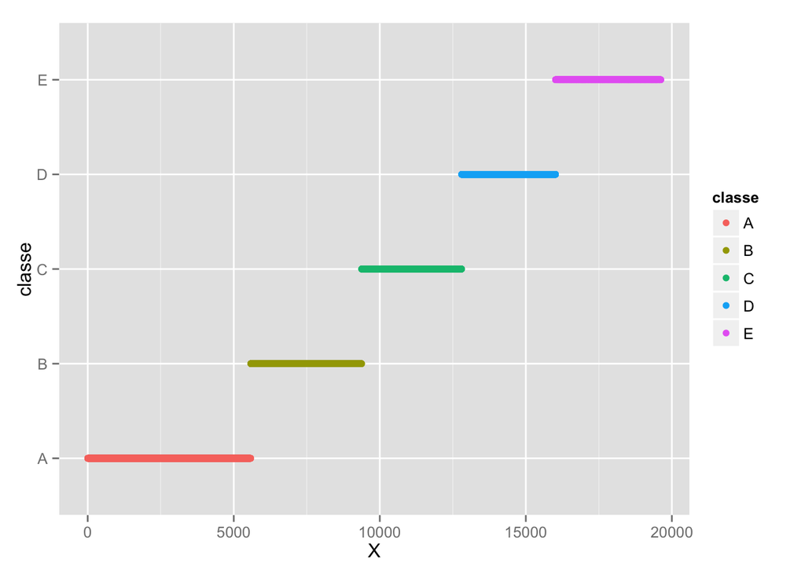

[figure not shown]

```r
ggplot(data = training, aes(x = X, y = classe, color=classe)) + geom_point()
```

Lets look on variables in this dataset. I want to find out if some of variables have significant percentage of NAs and also want to see unique count of different values.

```r
na_count <- as.data.frame(sapply(training, function(x) (sum(is.na(x)))*100/length(x) ) )
unique_count <- as.data.frame(sapply(training, function(x) (length(unique(x))) ) )
data_check <- cbind(na_count, unique_count)
colnames(data_check)<-c("% of NAs", "Unique values")
```

```r
knitr::kable(data_check)
```

|  | % of NAs | Unique values |
| --- | --- | --- |
| X | 0.00000 | 11776 |
| user_name | 0.00000 | 6 |
| raw_timestamp_part_1 | 0.00000 | 836 |
| raw_timestamp_part_2 | 0.00000 | 10668 |
| cvtd_timestamp | 0.00000 | 20 |
| new_window | 0.00000 | 2 |
| num_window | 0.00000 | 857 |
| roll_belt | 0.00000 | 994 |
| pitch_belt | 0.00000 | 1602 |
| yaw_belt | 0.00000 | 1703 |
| total_accel_belt | 0.00000 | 28 |
| kurtosis_roll_belt | 0.00000 | 230 |
| kurtosis_picth_belt | 0.00000 | 194 |
| kurtosis_yaw_belt | 0.00000 | 2 |
| skewness_roll_belt | 0.00000 | 231 |
| skewness_roll_belt.1 | 0.00000 | 200 |
| skewness_yaw_belt | 0.00000 | 2 |
| max_roll_belt | 97.99592 | 140 |
| max_picth_belt | 97.99592 | 20 |
| max_yaw_belt | 0.00000 | 60 |
| min_roll_belt | 97.99592 | 131 |
| min_pitch_belt | 97.99592 | 15 |
| min_yaw_belt | 0.00000 | 60 |
| amplitude_roll_belt | 97.99592 | 105 |
| amplitude_pitch_belt | 97.99592 | 12 |
| amplitude_yaw_belt | 0.00000 | 4 |
| var_total_accel_belt | 97.99592 | 41 |
| avg_roll_belt | 97.99592 | 128 |
| stddev_roll_belt | 97.99592 | 48 |
| var_roll_belt | 97.99592 | 58 |

[output cut: 130 more lines]

I plot featurePlot for some of predictors from this list.

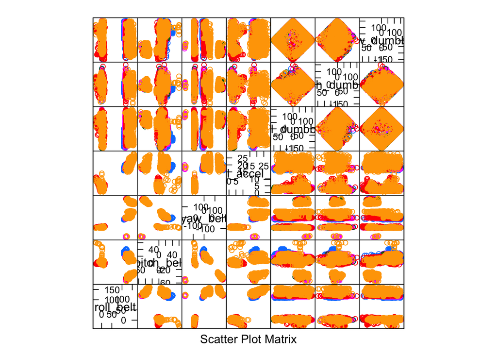

```r
featurePlot(x = training[, c("roll_belt", "pitch_belt", "yaw_belt", "total_accel_belt",
                             "roll_dumbbell", "pitch_dumbbell", "yaw_dumbbell")],
            y = training$classe, plot = "pairs")
```

And based on this chart I think most appropriate machine learning algorithm is tree based (I plan to use random forest and tree bag). From this perspective I try to decrease number of predictors because significant time required to build model based on big number of variables.

# Building Predicting Model

## Using Decision Tree algorithm

```r
modelFit1 <- train(classe ~ roll_belt+pitch_belt+yaw_belt+total_accel_belt+
                     gyros_belt_x+gyros_belt_y+gyros_belt_z+
                     accel_belt_x+accel_belt_y+accel_belt_z+
                     magnet_belt_x+magnet_belt_y+magnet_belt_z+
                     roll_arm+pitch_arm+
                     yaw_arm+total_accel_arm+
                     gyros_arm_x+gyros_arm_y+gyros_arm_z+
                     accel_arm_x+accel_arm_y+accel_arm_z+
                     magnet_arm_x+magnet_arm_y+magnet_arm_z+
                     roll_dumbbell+pitch_dumbbell+yaw_dumbbell
                     , method = "rpart",
                   data = training)
```

```r
print(modelFit1)
```

```
## CART
##
## 11776 samples
##   159 predictor
##     5 classes: 'A', 'B', 'C', 'D', 'E'
##
## No pre-processing
## Resampling: Bootstrapped (25 reps)
##
## Summary of sample sizes: 11776, 11776, 11776, 11776, 11776, 11776, ...
##
## Resampling results across tuning parameters:
##
##   cp          Accuracy   Kappa       Accuracy SD  Kappa SD
##   0.02384907  0.5119638  0.37689295  0.02521634   0.03047300
##   0.02812055  0.4929280  0.35270457  0.02007708   0.02395389
##   0.11651637  0.3390775  0.08487672  0.04021478   0.05953774
##
## Accuracy was used to select the optimal model using  the largest value.
## The final value used for the model was cp = 0.02384907.
```

Lets validate this model against our testing dataset

```r
predictions <- predict(modelFit1, newdata = testing)
C1 <- confusionMatrix(predictions, testing$classe)
print(C1)
```

```
## Confusion Matrix and Statistics
##
##           Reference
## Prediction    A    B    C    D    E
##          A 1273  255  284  110   65
##          B  459  993  351  557  596
##          C   67  154  370   25   78
##          D  429  116  363  594   64
##          E    4    0    0    0  639
##
## Overall Statistics
##
##                Accuracy : 0.4931
##                  95% CI : (0.482, 0.5042)
##     No Information Rate : 0.2845
##     P-Value [Acc > NIR] : < 2.2e-16
##
##                   Kappa : 0.3599
##  Mcnemar's Test P-Value : < 2.2e-16
##
## Statistics by Class:
##
##                      Class: A Class: B Class: C Class: D Class: E
## Sensitivity            0.5703   0.6542  0.27047  0.46190  0.44313
## Specificity            0.8728   0.6898  0.94998  0.85183  0.99938
## Pos Pred Value         0.6407   0.3359  0.53314  0.37931  0.99378
## Neg Pred Value         0.8363   0.8926  0.86046  0.88981  0.88852
## Prevalence             0.2845   0.1935  0.17436  0.16391  0.18379
## Detection Rate         0.1622   0.1266  0.04716  0.07571  0.08144
## Detection Prevalence   0.2533   0.3768  0.08845  0.19959  0.08195
## Balanced Accuracy      0.7216   0.6720  0.61023  0.65686  0.72125
```

As we see result is not very good.

## Using Random Forests algorithm

```r
modelFit2 <- train(classe ~ roll_belt+pitch_belt+yaw_belt+total_accel_belt+
                     gyros_belt_x+gyros_belt_y+gyros_belt_z+
                     accel_belt_x+accel_belt_y+accel_belt_z+
                     magnet_belt_x+magnet_belt_y+magnet_belt_z+
                     roll_arm+pitch_arm+
                     yaw_arm+total_accel_arm+
                     gyros_arm_x+gyros_arm_y+gyros_arm_z+
                     accel_arm_x+accel_arm_y+accel_arm_z+
                     magnet_arm_x+magnet_arm_y+magnet_arm_z+
                     roll_dumbbell+pitch_dumbbell+yaw_dumbbell, method = "rf",
                  data = training)
```

```r
print(modelFit2)
```

```
## Random Forest
##
## 11776 samples
##   159 predictor
##     5 classes: 'A', 'B', 'C', 'D', 'E'
##
## No pre-processing
## Resampling: Bootstrapped (25 reps)
##
## Summary of sample sizes: 11776, 11776, 11776, 11776, 11776, 11776, ...
##
## Resampling results across tuning parameters:
##
##   mtry  Accuracy   Kappa      Accuracy SD  Kappa SD
##    2    0.9678426  0.9593410  0.003628465  0.004596567
##   15    0.9680027  0.9595431  0.003948202  0.005000511
##   29    0.9591265  0.9483189  0.005170150  0.006557534
##
## Accuracy was used to select the optimal model using  the largest value.
## The final value used for the model was mtry = 15.
```

Lets run cross validation on **testing** dataset (out-of-sample data)

```r
predictions <- predict(modelFit2, newdata = testing)
C2 <- confusionMatrix(predictions, testing$classe)
print(C2)
```

```
## Confusion Matrix and Statistics
##
##           Reference
## Prediction    A    B    C    D    E
##          A 2194   19    6    8    4
##          B   11 1478   22    0    7
##          C    9   19 1326   27    6
##          D   13    1   14 1246    2
##          E    5    1    0    5 1423
##
## Overall Statistics
##
##                Accuracy : 0.9772
##                  95% CI : (0.9736, 0.9804)
##     No Information Rate : 0.2845
##     P-Value [Acc > NIR] : < 2e-16
##
##                   Kappa : 0.9711
##  Mcnemar's Test P-Value : 0.01999
##
## Statistics by Class:
##
##                      Class: A Class: B Class: C Class: D Class: E
## Sensitivity            0.9830   0.9736   0.9693   0.9689   0.9868
## Specificity            0.9934   0.9937   0.9906   0.9954   0.9983
## Pos Pred Value         0.9834   0.9736   0.9560   0.9765   0.9923
## Neg Pred Value         0.9932   0.9937   0.9935   0.9939   0.9970
## Prevalence             0.2845   0.1935   0.1744   0.1639   0.1838
## Detection Rate         0.2796   0.1884   0.1690   0.1588   0.1814
## Detection Prevalence   0.2843   0.1935   0.1768   0.1626   0.1828
## Balanced Accuracy      0.9882   0.9837   0.9799   0.9822   0.9926
```

Result on testing dataset is good.

## Using Bagged CART algorithm

```r
modelFit3 <- train(classe ~ roll_belt+pitch_belt+yaw_belt+total_accel_belt+
                     gyros_belt_x+gyros_belt_y+gyros_belt_z+
                     accel_belt_x+accel_belt_y+accel_belt_z+
                     magnet_belt_x+magnet_belt_y+magnet_belt_z+
                     roll_arm+pitch_arm+
                     yaw_arm+total_accel_arm+
                     gyros_arm_x+gyros_arm_y+gyros_arm_z+
                     accel_arm_x+accel_arm_y+accel_arm_z+
                     magnet_arm_x+magnet_arm_y+magnet_arm_z+
                     roll_dumbbell+pitch_dumbbell+yaw_dumbbell, method = "treebag",
                   data = training)
```

```r
print(modelFit3)
```

```
## Bagged CART
##
## 11776 samples
##   159 predictor
##     5 classes: 'A', 'B', 'C', 'D', 'E'
##
## No pre-processing
## Resampling: Bootstrapped (25 reps)
##
## Summary of sample sizes: 11776, 11776, 11776, 11776, 11776, 11776, ...
##
## Resampling results
##
##   Accuracy   Kappa      Accuracy SD  Kappa SD
##   0.9578813  0.9467415  0.004642844  0.005848128
##
##
```

Lets estimate perfromance of modelFit3 on testing dataset

```r
predictions <- predict(modelFit3, newdata = testing)
C3 <- confusionMatrix(predictions, testing$classe)
print(C3)
```

```
## Confusion Matrix and Statistics
##
##           Reference
## Prediction    A    B    C    D    E
##          A 2172   28   10   14    4
##          B   20 1458   23    2   15
##          C   12   24 1318   22    5
##          D   18    5   16 1244    1
##          E   10    3    1    4 1417
##
## Overall Statistics
##
##                Accuracy : 0.9698
##                  95% CI : (0.9658, 0.9735)
##     No Information Rate : 0.2845
##     P-Value [Acc > NIR] : < 2e-16
##
##                   Kappa : 0.9618
##  Mcnemar's Test P-Value : 0.03653
##
## Statistics by Class:
##
##                      Class: A Class: B Class: C Class: D Class: E
## Sensitivity            0.9731   0.9605   0.9635   0.9673   0.9827
## Specificity            0.9900   0.9905   0.9903   0.9939   0.9972
## Pos Pred Value         0.9749   0.9605   0.9544   0.9688   0.9875
## Neg Pred Value         0.9893   0.9905   0.9923   0.9936   0.9961
## Prevalence             0.2845   0.1935   0.1744   0.1639   0.1838
## Detection Rate         0.2768   0.1858   0.1680   0.1586   0.1806
## Detection Prevalence   0.2840   0.1935   0.1760   0.1637   0.1829
## Balanced Accuracy      0.9816   0.9755   0.9769   0.9806   0.9899
```

## Final conclusion

Lets run our prediction on test dataset

```r
answer_prediction <- predict(modelFit2, newdata = test_data)
print(answer_prediction)
```

```
##  [1] B A B A A E D B A A B C B A E E A B B B
## Levels: A B C D E
```